# Assignment 5: Handle Missing Values

*How to do it?*:

- Open the Rmarkdown file of this assignment (link) in Rstudio.
- Right under each **question**, insert a code chunk (you can use the hotkey `Ctrl + Alt + I` to add a code chunk) and code the solution for the question.
- `Knit` the rmarkdown file (hotkey: `Ctrl + Alt + K`) to export an html.
- Publish the html file to your Githiub Page.

*Submission*: Submit the link on Github of the assignment to Canvas.

**The data:**

This assignment works with the Adult Census Data that can be downloaded at [this link.](https://bryantstats.github.io/math421/data/adult_census_missing.csv)

**Questions**

1. Use `read_csv` to import the data. Show the number of NAs for each columns.

```r
library(tidyverse)
df <- read.csv('adult_census_missing.csv')
colSums(is.na(df))
```

```
##            age      workclass         fnlwgt      education  education.num
##             30              0              0              0              0
## marital.status     occupation   relationship           race            sex
##              0              0              0              0              0
##   capital.gain   capital.loss hours.per.week native.country         income
##              8              0              0              0              0
```

2. Using function `aggr` the VIM package to plot the number of NAs for each column.

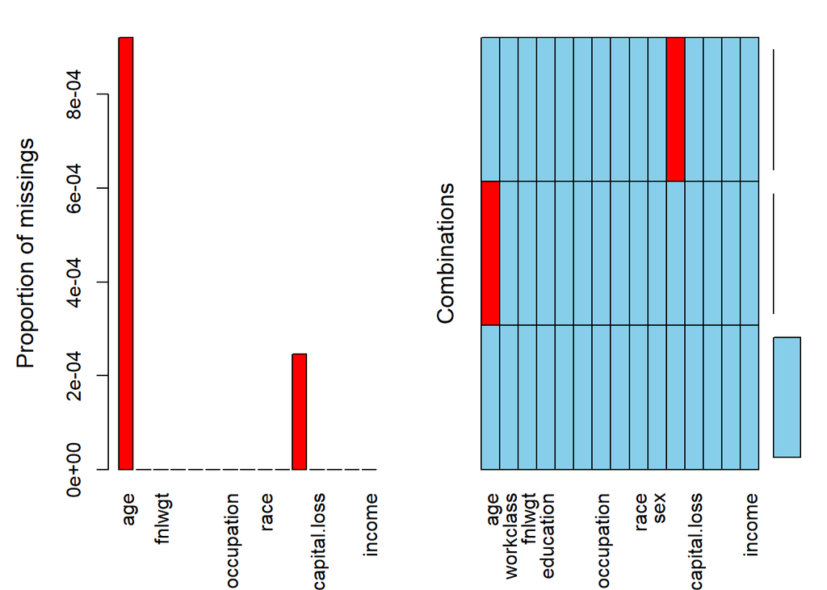

```r
#install.packages("VIM")
library(VIM)
df %>% aggr
```

3. Find other forms of missing values. Hint: You can use the `table` function to check if there are suspicious categories (Unknown, for example) in a variable. What all other forms of missing values shown in the data.

```r
table(df$occupation)
```

```
##
##                                   ?      Adm-clerical      Armed-Forces
##                35              1840              3761                 9
##      Craft-repair   Exec-managerial   Farming-fishing Handlers-cleaners
##              4090              4059               993              1368
## Machine-op-inspct         Not Known     Other-service   Priv-house-serv
##              2001                12              3287               149
##    Prof-specialty   Protective-serv             Sales      Tech-support
##              4132               647              3647               924
##  Transport-moving           Unknown
##              1594                13
```

```r
table(df$marital.status)
```

```
##
##                                    Divorced     Married-AF-spouse
##                    26                  4435                    23
##    Married-civ-spouse Married-spouse-absent         Never-married
##                 14963                   418                 10666
##             Not Known             Separated               Widowed
##                    12                  1025                   993
```

4. Replace all the forms of missing values found to NA

```r
df <- df %>%
  na_if("Not known") %>%
  na_if("?") %>%
  na_if("Unknown")
```

5. Replot the number of NAs for each column.

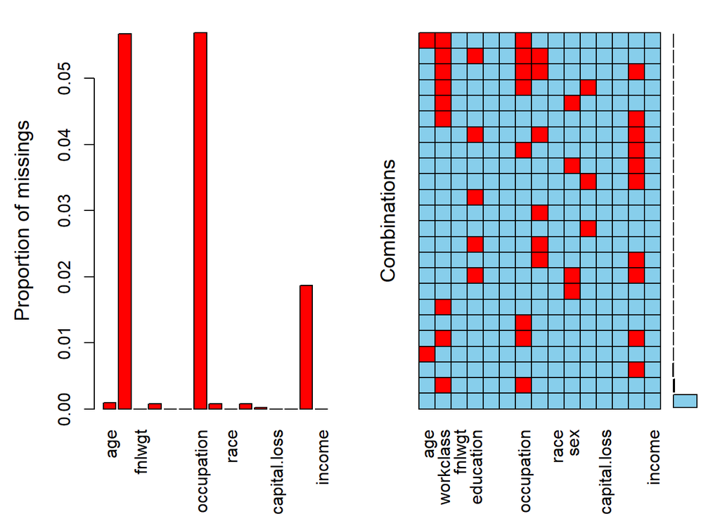

```r
df %>% aggr
```

6. Approach 1 to handle NAs: remove all rows that have any NAs. Save the dataset after removing as a different data. The original data is unchanged (still have NAs). How many rows left after removing?

```r
dfDrop <- drop_na(df)
size_sum(dfDrop)
```

```
## [1] "[30,052 × 15]"
```

7. Approach 2 to handle NAs: Fill all the NAs with the previous or next value. (Hint: Using `fill` function). Save the dataset after filling as a different data. The original data is unchanged (still have NAs).

```r
dfFill <- df %>% fill(age, workclass, education, marital.status, occupation, relationship, sex, capital.gain, native.country, .direction = 'up')

size_sum(dfFill)
```

```
## [1] "[32,561 × 15]"
```

8. Approach 3 to handle NAs: For numeric variable, replace the NAs by the median. For categorical variables, replace the NAs to the majority.

```r
majority_marital.status <- names(which.max(table(df$marital.status)))
df$marital.status <- replace_na(df$marital.status, majority_marital.status)

majority_occupation <- names(which.max(table(df$occupation)))
df$occupation <- replace_na(df$occupation, majority_occupation)

majority_native.country <- names(which.max(table(df$native.country)))
df$native.country <- replace_na(df$native.country, majority_native.country)

median_age <- median(df$age, na.rm = TRUE)
df$age <- replace_na(df$age, median_age)

median_capital.gain <- median(df$capital.gain, na.rm = TRUE)
df$capital.gain <- replace_na(df$capital.gain, median_capital.gain)

majority_workclass <- names(which.max(table(df$workclass)))
df$workclass <- replace_na(df$workclass, majority_workclass)

majority_education <- names(which.max(table(df$education)))
df$education <- replace_na(df$education, majority_education)

majority_relationship <- names(which.max(table(df$relationship)))
df$relationship <- replace_na(df$relationship, majority_relationship)

majority_sex <- names(which.max(table(df$sex)))
df$sex <- replace_na(df$sex, majority_sex)

colSums(is.na(df))
```

```
##            age      workclass         fnlwgt      education  education.num
##              0              0              0              0              0
## marital.status     occupation   relationship           race            sex
##              0              0              0              0              0
##   capital.gain   capital.loss hours.per.week native.country         income
##              0              0              0              0              0
```

```r
size_sum(df)
```

```
## [1] "[32,561 × 15]"
```